# Chapitre 5

```r
library(tidyverse)
```

## Exercice 5.1 : Les prénoms aux USA

1. Commençons par une solution en R classique

```r
library(babynames)
babynames2000 <- babynames[babynames$year==2000,]
babynames2000_split <- split(babynames2000, babynames2000$sex)
babynames2000_split_top10 <- lapply(babynames2000_split, function(df) {df[order(df$n, decreasing = TRUE)[1:10],]})
babynames2000_top10 <- do.call(rbind, babynames2000_split_top10)
babynames2000_top10
```

|  | year | sex | name | n | prop |
| --- | --- | --- | --- | --- | --- |
| 1 | 2000 | F | Emily | 25953 | 0.01300980 |
| 2 | 2000 | F | Hannah | 23080 | 0.01156961 |
| 3 | 2000 | F | Madison | 19967 | 0.01000912 |
| 4 | 2000 | F | Ashley | 17997 | 0.00902159 |
| 5 | 2000 | F | Sarah | 17697 | 0.00887121 |
| 6 | 2000 | F | Alexis | 17629 | 0.00883712 |
| 7 | 2000 | F | Samantha | 17266 | 0.00865515 |
| 8 | 2000 | F | Jessica | 15709 | 0.00787466 |
| 9 | 2000 | F | Elizabeth | 15094 | 0.00756637 |
| 10 | 2000 | F | Taylor | 15078 | 0.00755835 |

[output cut: 10 more lines]

Avec **data.table**, on peut faire

```r
library(data.table)
babynames_dt <- data.table(babynames)
babynames2000_top10_dt <- babynames_dt[year == 2000,.SD[order(n, decreasing = TRUE)[1:10],], by = sex]
babynames2000_top10_dt
```

| sex | year | name | n | prop |
| --- | --- | --- | --- | --- |
| F | 2000 | Emily | 25953 | 0.01300980 |
| F | 2000 | Hannah | 23080 | 0.01156961 |
| F | 2000 | Madison | 19967 | 0.01000912 |
| F | 2000 | Ashley | 17997 | 0.00902159 |
| F | 2000 | Sarah | 17697 | 0.00887121 |
| F | 2000 | Alexis | 17629 | 0.00883712 |
| F | 2000 | Samantha | 17266 | 0.00865515 |
| F | 2000 | Jessica | 15709 | 0.00787466 |
| F | 2000 | Elizabeth | 15094 | 0.00756637 |
| F | 2000 | Taylor | 15078 | 0.00755835 |

[output cut: 10 more lines]

Enfin avec **dplyr**,

```r
babynames_tbl <- babynames
babynames2000_top10_tbl <- babynames_tbl %>%
  filter(year == 2000) %>%
  group_by(sex) %>%
  top_n(10, n) %>%
  arrange(desc(n), .by_group = TRUE)
babynames2000_top10_tbl
```

| year | sex | name | n | prop |
| --- | --- | --- | --- | --- |
| 2000 | F | Emily | 25953 | 0.01300980 |
| 2000 | F | Hannah | 23080 | 0.01156961 |
| 2000 | F | Madison | 19967 | 0.01000912 |
| 2000 | F | Ashley | 17997 | 0.00902159 |
| 2000 | F | Sarah | 17697 | 0.00887121 |
| 2000 | F | Alexis | 17629 | 0.00883712 |
| 2000 | F | Samantha | 17266 | 0.00865515 |
| 2000 | F | Jessica | 15709 | 0.00787466 |
| 2000 | F | Elizabeth | 15094 | 0.00756637 |
| 2000 | F | Taylor | 15078 | 0.00755835 |

[output cut: 10 more lines]

```r
babynames_split <- split(babynames,list(babynames$sex,babynames$year))
babynames_split_prop <- lapply(babynames_split,
                               function(df) {
                                 df <- df[order(df$prop, decreasing = TRUE)[1:10],]
                                 data.frame(year = df$year[[1]], sex = df$sex[[1]], prop_tot = sum(df$prop))
                               })
babynames_prop <- do.call(rbind, babynames_split_prop)
babynames_prop
```

|  | year | sex | prop_tot |
| --- | --- | --- | --- |
| F.1880 | 1880 | F | 0.22979356 |
| M.1880 | 1880 | M | 0.41262670 |
| F.1881 | 1881 | F | 0.22468261 |
| M.1881 | 1881 | M | 0.40747308 |
| F.1882 | 1882 | F | 0.22317301 |
| M.1882 | 1882 | M | 0.39798084 |
| F.1883 | 1883 | F | 0.21912561 |
| M.1883 | 1883 | M | 0.39652552 |
| F.1884 | 1884 | F | 0.21702790 |
| M.1884 | 1884 | M | 0.38439604 |

[output cut: 266 more lines]

- en **data.table**

```r
babynames_dt[, .SD[order(prop, decreasing = TRUE)[1:10],],by = c("sex", "year")][, .(prop_tot = sum(prop)), by = c("sex", "year")]
```

| sex | year | prop_tot |
| --- | --- | --- |
| F | 1880 | 0.22979356 |
| M | 1880 | 0.41262670 |
| F | 1881 | 0.22468261 |
| M | 1881 | 0.40747308 |
| F | 1882 | 0.22317301 |
| M | 1882 | 0.39798084 |
| F | 1883 | 0.21912561 |
| M | 1883 | 0.39652552 |
| F | 1884 | 0.21702790 |
| M | 1884 | 0.38439604 |

[output cut: 266 more lines]

- enfin en **dplyr**

```r
babynames %>% group_by(sex,year) %>% top_n(10,n) %>% summarise(sum_prop=sum(prop))
```

| sex | year | sum_prop |
| --- | --- | --- |
| F | 1880 | 0.22979356 |
| F | 1881 | 0.22468261 |
| F | 1882 | 0.22317301 |
| F | 1883 | 0.21912561 |
| F | 1884 | 0.21702790 |
| F | 1885 | 0.21233832 |
| F | 1886 | 0.20872930 |
| F | 1887 | 0.20583315 |
| F | 1888 | 0.20138298 |
| F | 1889 | 0.19967868 |

[output cut: 266 more lines]

3. On doit tout d’abord faire une jointure entre la table initiale et la table de la question 1. On somme ensuite les proportions associées à chaue prénom.
- En R classique ça donne

```r
babynames_merge <- merge(babynames2000_top10[,c("sex", "name")],babynames)
babynames_split <- split(babynames_merge,list(babynames_merge$sex,babynames_merge$year))
babynames_split_prop <- lapply(babynames_split,
                               function(df) {
                                 df <- df[order(df$prop, decreasing = TRUE),]
                                 data.frame(year = df$year[[1]], sex = df$sex[[1]], prop_tot = sum(df$prop))
                               })
babynames_prop <- do.call(rbind, babynames_split_prop)
babynames_prop
```

|  | year | sex | prop_tot |
| --- | --- | --- | --- |
| F.1880 | 1880 | F | 0.03776447 |
| M.1880 | 1880 | M | 0.04241552 |
| F.1881 | 1881 | F | 0.03577967 |
| M.1881 | 1881 | M | 0.04150275 |
| F.1882 | 1882 | F | 0.03548123 |
| M.1882 | 1882 | M | 0.04066181 |
| F.1883 | 1883 | F | 0.03488285 |
| M.1883 | 1883 | M | 0.04193746 |
| F.1884 | 1884 | F | 0.03442210 |
| M.1884 | 1884 | M | 0.04032980 |

[output cut: 266 more lines]

- en **data.table**

```r
babynames_dt[babynames2000_top10_dt[,c("sex", "name")],, on = c("sex", "name")][, .(prop_tot = sum(prop)), by = c("sex", "year")]
```

| sex | year | prop_tot |
| --- | --- | --- |
| F | 1880 | 0.03776447 |
| F | 1881 | 0.03577967 |
| F | 1882 | 0.03548123 |
| F | 1883 | 0.03488285 |
| F | 1884 | 0.03442210 |
| F | 1885 | 0.03248372 |
| F | 1886 | 0.03184700 |
| F | 1887 | 0.03059412 |
| F | 1888 | 0.03044154 |
| F | 1889 | 0.02928353 |

[output cut: 266 more lines]

- enfin en **dplyr**

```r
left_join(babynames2000_top10_tbl %>% select(sex, name),babynames_tbl) %>% group_by(sex,year) %>% summarize(prop2000=sum(prop))
```

| sex | year | prop2000 |
| --- | --- | --- |
| F | 1880 | 0.03776447 |
| F | 1881 | 0.03577967 |
| F | 1882 | 0.03548123 |
| F | 1883 | 0.03488285 |
| F | 1884 | 0.03442210 |
| F | 1885 | 0.03248372 |
| F | 1886 | 0.03184700 |
| F | 1887 | 0.03059412 |
| F | 1888 | 0.03044154 |
| F | 1889 | 0.02928353 |

[output cut: 266 more lines]

4. Pour simuler la base à distance, on commence par copier notre table à l’aide de **SQLite**

```r
library(DBI)
con <- dbConnect(RSQLite::SQLite())
dbWriteTable(con, name = "babynames",babynames, overwrite = TRUE)
```

On peut alors lancer des requêtes SQL avec *dbGetQuery*.

- Pour la question 1 on a

```r
dbGetQuery(con,
           'SELECT * FROM
           (SELECT *, RANK() OVER (PARTITION BY "sex" ORDER BY "n" DESC) as rank  FROM  babynames WHERE ("year" = 2000)) as TMP
           WHERE rank <= 10')
```

| year | sex | name | n | prop | rank |
| --- | --- | --- | --- | --- | --- |
| 2000 | F | Emily | 25953 | 0.01300980 | 1 |
| 2000 | F | Hannah | 23080 | 0.01156961 | 2 |
| 2000 | F | Madison | 19967 | 0.01000912 | 3 |
| 2000 | F | Ashley | 17997 | 0.00902159 | 4 |
| 2000 | F | Sarah | 17697 | 0.00887121 | 5 |
| 2000 | F | Alexis | 17629 | 0.00883712 | 6 |
| 2000 | F | Samantha | 17266 | 0.00865515 | 7 |
| 2000 | F | Jessica | 15709 | 0.00787466 | 8 |
| 2000 | F | Elizabeth | 15094 | 0.00756637 | 9 |
| 2000 | F | Taylor | 15078 | 0.00755835 | 10 |

[output cut: 10 more lines]

- pour la question 2

```r
dbGetQuery(con,
           'WITH babynames_top AS
           (SELECT *
           FROM
           (SELECT *, RANK() OVER (PARTITION BY sex,  "year" ORDER BY n DESC) as rank  FROM  babynames) as TMP
           WHERE rank <= 10)

           SELECT "year", sex, SUM(prop) as prop_tot FROM
           babynames_top
           GROUP BY "year", sex')
```

| year | sex | prop_tot |
| --- | --- | --- |
| 1880 | F | 0.22979356 |
| 1880 | M | 0.41262670 |
| 1881 | F | 0.22468261 |
| 1881 | M | 0.40747308 |
| 1882 | F | 0.22317301 |
| 1882 | M | 0.39798084 |
| 1883 | F | 0.21912561 |
| 1883 | M | 0.39652552 |
| 1884 | F | 0.21702790 |
| 1884 | M | 0.38439604 |

[output cut: 266 more lines]

- et enfin la question 3

```r
dbGetQuery(con,
           'WITH babynames_top2000 AS (
           SELECT *
           FROM
           (SELECT *, RANK() OVER (PARTITION BY "sex" ORDER BY "n" DESC) as rank  FROM  babynames WHERE ("year" = 2000)) as TMP
           WHERE rank <= 10
           ),
           babynames_merge AS (
            SELECT  babynames."year" as "year",
                    babynames.sex as sex,
                    babynames.name as name,
                    babynames.n as n,
                    babynames.prop as prop
            FROM
            babynames_top2000
            LEFT JOIN
            babynames ON (babynames_top2000.sex = babynames.sex AND babynames_top2000.name = babynames.name))
            SELECT "year", sex, SUM(prop) as prop_tot FROM
            babynames_merge
            GROUP BY "year", sex')
```

| year | sex | prop_tot |
| --- | --- | --- |
| 1880 | F | 0.03776447 |
| 1880 | M | 0.04241552 |
| 1881 | F | 0.03577967 |
| 1881 | M | 0.04150275 |
| 1882 | F | 0.03548123 |
| 1882 | M | 0.04066181 |
| 1883 | F | 0.03488285 |
| 1883 | M | 0.04193746 |
| 1884 | F | 0.03442210 |
| 1884 | M | 0.04032980 |

[output cut: 266 more lines]

Une alternative aux requêtes SQL est l’utilisation du package **dbplyr** :

```r
babynames_sql <- tbl(con, "babynames")
```

- On obtient pour la question 1

```r
babynames2000_sql <- babynames_sql %>%
  filter(year == 2000) %>%
  group_by(sex)

babynames2000_top10_sql <- babynames2000_sql %>% collect() %>% top_n(10,n)
babynames2000_top10_sql
```

| year | sex | name | n | prop |
| --- | --- | --- | --- | --- |
| 2000 | F | Emily | 25953 | 0.01300980 |
| 2000 | F | Hannah | 23080 | 0.01156961 |
| 2000 | F | Madison | 19967 | 0.01000912 |
| 2000 | F | Ashley | 17997 | 0.00902159 |
| 2000 | F | Sarah | 17697 | 0.00887121 |
| 2000 | F | Alexis | 17629 | 0.00883712 |
| 2000 | F | Samantha | 17266 | 0.00865515 |
| 2000 | F | Jessica | 15709 | 0.00787466 |
| 2000 | F | Elizabeth | 15094 | 0.00756637 |
| 2000 | F | Taylor | 15078 | 0.00755835 |

[output cut: 10 more lines]

- Pour la question 2

```r
babynames_sql %>% group_by(sex,year) %>% arrange(desc(n),.by_group=TRUE) %>% collect() %>% top_n(10,n) %>% summarise(sum_prop=sum(prop))
```

| sex | year | sum_prop |
| --- | --- | --- |
| F | 1880 | 0.22979356 |
| F | 1881 | 0.22468261 |
| F | 1882 | 0.22317301 |
| F | 1883 | 0.21912561 |
| F | 1884 | 0.21702790 |
| F | 1885 | 0.21233832 |
| F | 1886 | 0.20872930 |
| F | 1887 | 0.20583315 |
| F | 1888 | 0.20138298 |
| F | 1889 | 0.19967868 |

[output cut: 266 more lines]

- et enfin pour la question 3

```r
dbWriteTable(con, name = "babynames2000_top10_sql",babynames2000_top10_sql, overwrite = TRUE)
babynames2000_top10_sql <- tbl(con, "babynames2000_top10_sql")

left_join(babynames2000_top10_sql %>% select(sex, name),babynames_sql) %>% group_by(sex,year) %>% summarize(prop2000=sum(prop))
```

| sex | year | prop2000 |
| --- | --- | --- |
| F | 1880 | 0.03776447 |
| F | 1881 | 0.03577967 |
| F | 1882 | 0.03548123 |
| F | 1883 | 0.03488285 |
| F | 1884 | 0.03442210 |
| F | 1885 | 0.03248372 |
| F | 1886 | 0.03184700 |
| F | 1887 | 0.03059412 |
| F | 1888 | 0.03044154 |
| F | 1889 | 0.02928353 |

[output cut: 266 more lines]

Et on n’oublie pas de se déconnecter !

```r
dbDisconnect(con)
```

## Exercice 5.2 : Les tournois majeurs au tennis en 2013

1. On utilise **read_csv** pour travailler avec un **tibble**.

```r
df <- read_csv("FrenchOpen-men-2013.csv")
```

```r
df %>% distinct(Player1)
```

| Player1 |
| --- |
| Pablo Carreno-Busta |
| Somdev Devvarman |
| Tobias Kamke |
| Julien Benneteau |
| Lukas Lacko |
| Jan Hajek |
| Adrian Mannarino |
| Gilles Simon |
| Philipp Petzschner |
| Radek Stepanek |

[output cut: 71 more lines]

```r
df %>% distinct(Player2)
```

| Player2 |
| --- |
| Roger Federer |
| Daniel Munoz-De La Nava |
| Paolo Lorenzi |
| Ricardas Berankis |
| Sam Querrey |
| Denis Kudla |
| Pablo Cuevas |
| Lleyton Hewitt |
| Marin Cilic |
| Nick Kyrgios |

[output cut: 69 more lines]

```r
df %>% filter(Player1=="Roger Federer" | Player2=="Roger Federer") %>% select(contains("Play"))
```

| Player1 | Player2 |
| --- | --- |
| Pablo Carreno-Busta | Roger Federer |
| Somdev Devvarman | Roger Federer |
| Julien Benneteau | Roger Federer |
| Gilles Simon | Roger Federer |
| Jo-Wilfried Tsonga | Roger Federer |

```r
df %>% filter(Round==6) %>% select(contains("Play"))
```

| Player1 | Player2 |
| --- | --- |
| David Ferrer | Jo-Wilfried Tsonga |
| Novak Djokovic | Rafael Nadal |

```r
df %>% mutate(nb_points=TPW.1+TPW.2) %>% summarise(nb_points_moy=mean(nb_points))
```

| nb_points_moy |
| --- |
| 219.44 |

```r
df %>% mutate(nb_ace=ACE.1+ACE.2) %>% group_by(Round) %>%
  summarise(min=min(nb_ace),max=max(nb_ace),moy=mean(nb_ace))
```

| Round | min | max | moy |
| --- | --- | --- | --- |
| 1 | 3 | 37 | 13.47619 |
| 2 | 2 | 38 | 13.19355 |
| 3 | 2 | 42 | 12.56250 |
| 4 | 1 | 23 | 9.12500 |
| 5 | 2 | 15 | 7.00000 |
| 6 | 9 | 11 | 10.00000 |
| 7 | 6 | 6 | 6.00000 |

```r
df %>% mutate(dbf=DBF.1+DBF.2) %>% summarize(tot.df=sum(dbf,na.rm=TRUE))
```

| tot.df |
| --- |
| 812 |

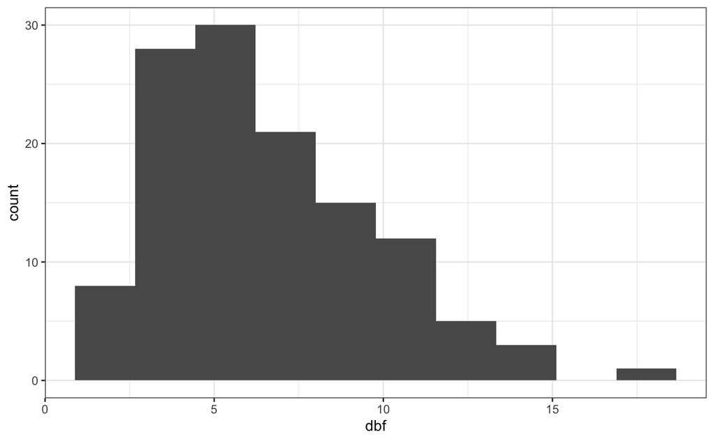

```r
df %>% mutate(dbf=DBF.1+DBF.2) %>% ggplot() + aes(x=dbf) + geom_histogram(bins=10) + theme_bw()
```

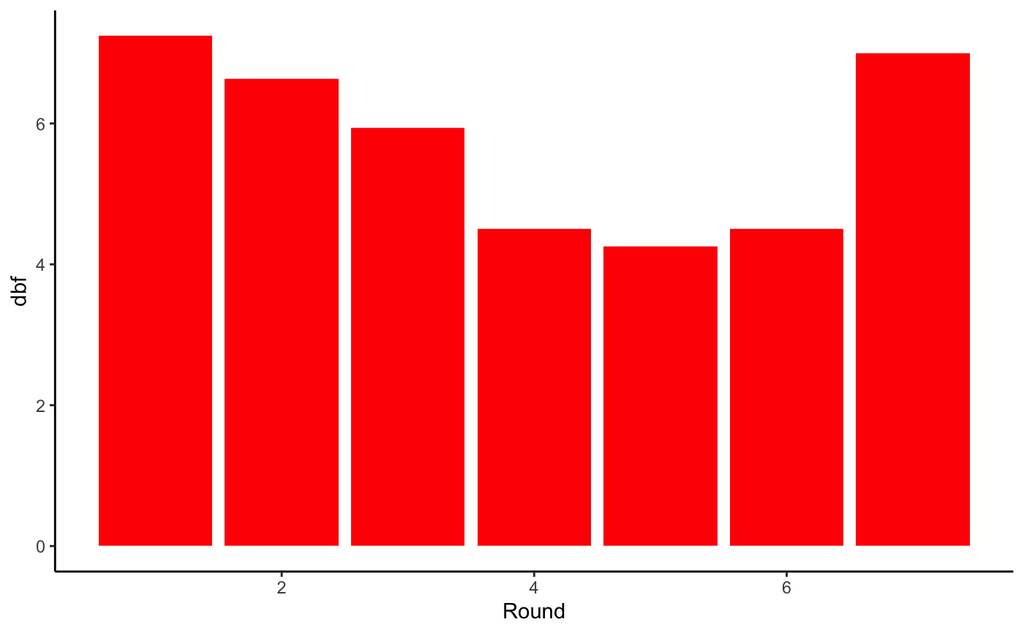

```r
df %>% mutate(dbf=DBF.1+DBF.2) %>% group_by(Round) %>% summarize(dbf=mean(dbf,na.rm=TRUE)) %>%
  ggplot() + aes(x=Round,y=dbf) + geom_bar(stat="identity",fill="red") + theme_classic()
```

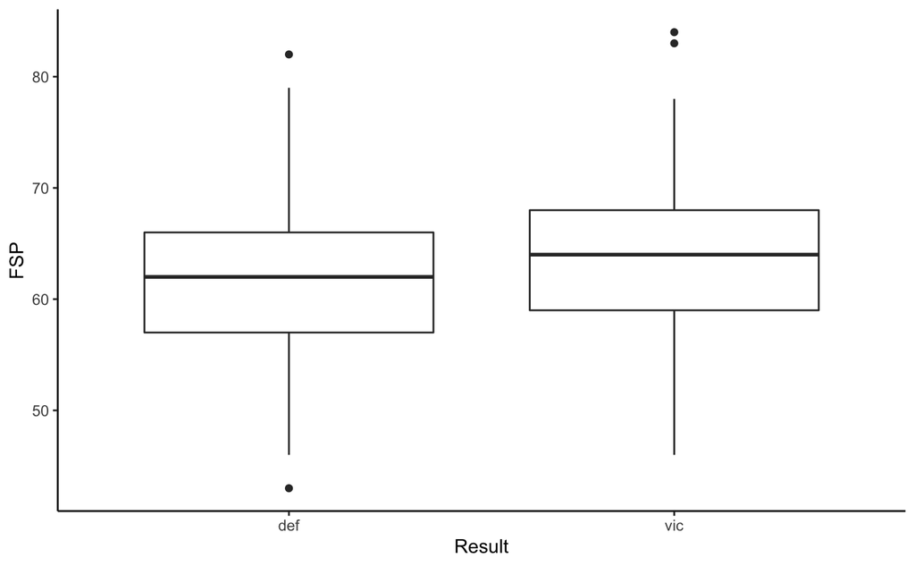

```r
df %>% select(Result,FSP.1,FSP.2) %>% gather(key="Player",value="FSP",-Result) %>%
  mutate(Result=as.character((Result==1 & Player=="FSP.1") | (Result==0 & Player=="FSP.2"))) %>%
  mutate(Result=fct_recode(Result,vic="TRUE",def="FALSE")) %>%
  ggplot() + aes(x=Result,y=FSP)+geom_boxplot()+theme_classic()
```

Il semble qu’il y ait une légère influence du pourcentage de premier service sur le résultat. On effectue un test de comparaison de moyennes pour vérifier :

```r
df1 <- df %>% select(Result,FSP.1,FSP.2) %>% gather(key="Player",value="FSP",-Result) %>%
  mutate(Result=as.character((Result==1 & Player=="FSP.1") | (Result==0 & Player=="FSP.2"))) %>%
  mutate(Result=fct_recode(Result,vic="TRUE",def="FALSE"))
t.test(FSP~Result,data=df1)
```

```
    Welch Two Sample t-test

data:  FSP by Result
t = -1.8395, df = 247.3, p-value = 0.06704
alternative hypothesis: true difference in means is not equal to 0
95 percent confidence interval:
 -3.6279302  0.1239302
sample estimates:
mean in group def mean in group vic
           61.536            63.288
```

Au niveau 10%, on concluera qu’il y a une influence.

## Exercice 5.3 : Le vélo STAR, encore !

1. On importe les tables

```r
url <- paste0(
"https://data.rennesmetropole.fr/api/records/1.0/search/",
"?dataset=etat-des-stations-le-velo-star-en-temps-reel",
"&rows=100",
"&facet=nom",
"&facet=etat",
"&facet=nombreemplacementsactuels",
"&facet=nombreemplacementsdisponibles",
"&facet=nombrevelosdisponibles",
"&facet=coordonnees"
)
ll <- jsonlite::fromJSON(url)
etat <- ll$records$fields
```

```r
url1 <- paste0(
"https://data.rennesmetropole.fr/api/records/1.0/search/",
"?dataset=topologie-des-stations-le-velo-star",
"&rows=100")
ll1 <- jsonlite::fromJSON(url1)
topo <- ll1$records$fields
```

2. On créé la table demandée

```r
glimpse(etat)
```

```
Observations: 55
Variables: 8
$ etat                          <chr> "En fonctionnement", "En fonctionnement", "En fonctionnement", "En fonctionnement", "En fonctionnement", "En fonctionne…
$ lastupdate                    <chr> "2020-03-15T16:59:10+00:00", "2020-03-15T16:59:10+00:00", "2020-03-15T16:59:10+00:00", "2020-03-15T16:59:10+00:00", "20…
$ nombrevelosdisponibles        <int> 6, 3, 21, 10, 14, 4, 8, 1, 9, 16, 15, 5, 12, 13, 4, 0, 15, 7, 27, 8, 1, 8, 9, 9, 10, 11, 3, 6, 6, 11, 20, 15, 11, 7, 4,…
$ nombreemplacementsactuels     <int> 16, 24, 23, 24, 20, 24, 18, 18, 16, 28, 20, 24, 24, 26, 28, 18, 20, 20, 30, 28, 16, 28, 20, 20, 24, 16, 30, 18, 14, 25,…
$ nom                           <chr> "Musée Beaux-Arts", "Champs Libres", "La Criée", "Brest - Verdun", "Marbeuf", "Plaine de Baud", "Gros-Chêne", "Painlevé…
$ nombreemplacementsdisponibles <int> 10, 21, 2, 14, 6, 20, 10, 17, 7, 12, 5, 19, 12, 13, 24, 18, 5, 13, 3, 20, 15, 20, 11, 11, 14, 5, 27, 12, 8, 14, 4, 7, 5…
$ idstation                     <chr> "5510", "5516", "5521", "5534", "5538", "5546", "5578", "5580", "5581", "5582", "5587", "5502", "5505", "5506", "5512",…
$ coordonnees                   <list> [<48.10960, -1.67408>, <48.105537, -1.674328>, <48.107626, -1.680085>, <48.113009, -1.693264>, <48.111749, -1.702077>,…
```

```r
latlong <- etat$coordonnees %>% unlist() %>% matrix(ncol=2,byrow=T) %>% as.data.frame()
names(latlong) <- c("latitude","longitude")
etat1 <- bind_cols(etat,latlong) %>% select(-coordonnees)
df <- inner_join(etat1,topo,by="nom") %>% select(id,nom,idstationproche1,latitude,longitude) %>% mutate(id=as.numeric(id))
df1 <- left_join(df,df,by=c("idstationproche1"="id")) %>% mutate(dist=(latitude.x-latitude.y)^2+(longitude.x-longitude.y)^2)
```

3. On calcule les stations les plus proches du point demandé

```r
etat1 %>% mutate(distance=(latitude-48.1179151)^2+(longitude+1.7028661)^2) %>% arrange(distance) %>% head(3) %>%
  arrange(distance,nombreemplacementsdisponibles) %>% select(nom,distance,nombreemplacementsdisponibles)
```

| nom | distance | nombreemplacementsdisponibles |
| --- | --- | --- |
| Berger | 7.540436e-06 | 8 |
| Villejean-Université | 1.156857e-05 | 21 |
| Marbeuf | 3.864347e-05 | 6 |

## Exercice 5.4 : Se cultiver par hasard

```r
library(rvest)
```

1. On se connecte à la page **wikipedia**

```r
wikipedia <- "https://fr.wikipedia.org/"
accueil <- "wiki/Wikipédia:Accueil_principal"
url0 <- paste0(wikipedia,accueil)
data_html <- read_html(url0)
```

2. On obtient les liens de la page avec

```r
internal_links <- 'a[href*="/wiki/"]:not([href*="//"])'
lien0 <- data_html %>% html_nodes(internal_links) %>% html_attr("href")
head(lien0)
```

```
[1] "/wiki/Wikip%C3%A9dia:Accueil_de_la_communaut%C3%A9" "/wiki/Aide:D%C3%A9buter"
[3] "/wiki/Portail:Accueil"                              "/wiki/Wikip%C3%A9dia:Principes_fondateurs"
[5] "/wiki/Aide:Accueil"                                 "/wiki/Aide:Poser_une_question"
```

4. On choisit une page au hasard

```r
set.seed(123)
lien_sel <- lien0 %>% sample(1)
lien_sel
```

```
[1] "/wiki/Guerre_civile_syrienne"
```

que l’on lit puis, sur laquelle on rechoisit une page au hasard

```r
set.seed(1234)
url1 <- paste0(wikipedia,lien_sel)
read_html(url1) %>% html_nodes(internal_links) %>% html_attr("href") %>% sample(1)
```

```
[1] "/wiki/Front_islamique_de_lib%C3%A9ration_syrien"
```

5. On peut écrire une fonction qui sélectionne un lien aléatoirement sur une page donnée :

```r
select_link <- function(url){
  read_html(url) %>%
    html_nodes(internal_links) %>%
    html_attr("href") %>%
    sample(1)
}
```

On peut ainsi en déduire les pages visitées pendand un nombre de jour donnée :

```r
library(magrittr)
pages_visitees <- function(nb_jours){
  liens_visites <- c()
  for(i in 1:nb_jours){
    wikipedia %>%
      select_link() %T>%
      {liens_visites <<- append(liens_visites, .)} %>%
      str_c(wikipedia, .) %>%
      select_link() %>%
      {liens_visites <<- append(liens_visites, .)}
  }
  return(unique(liens_visites))
}
```

6. Par exemple en 10 ans on aura visité :

```r
pages_10ans <- pages_visitees(3652)
head(pages_10ans)
```

```
[1] "/wiki/%C3%89lection_pr%C3%A9sidentielle_fran%C3%A7aise_de_1981" "/wiki/Syst%C3%A8me_mon%C3%A9taire_europ%C3%A9en"
[3] "/wiki/Wikip%C3%A9dia:V%C3%A9rifiabilit%C3%A9"                   "/wiki/Wikip%C3%A9dia:R%C3%A8gles_et_recommandations"
[5] "/wiki/44_av._J.-C."                                             "/wiki/Marcus_Junius_Brutus"
```

```r
length(pages_10ans)
```

```
[1] 2583
```

7. On peut renouveler le protocole 20 fois (il faudrait plus mais c’est très long !):

```r
set.seed(1234)
nb_visite <- rep(0,20)
for (i in 1:20){
  nb_visite[i] <- pages_visitees(3652) %>% length()
}
```

On peut regarder le résumé

```r
summary(nb_visite)
```

```
   Min. 1st Qu.  Median    Mean 3rd Qu.    Max.
   2520    2545    2563    2566    2585    2629
```

et visualiser l’histogramme

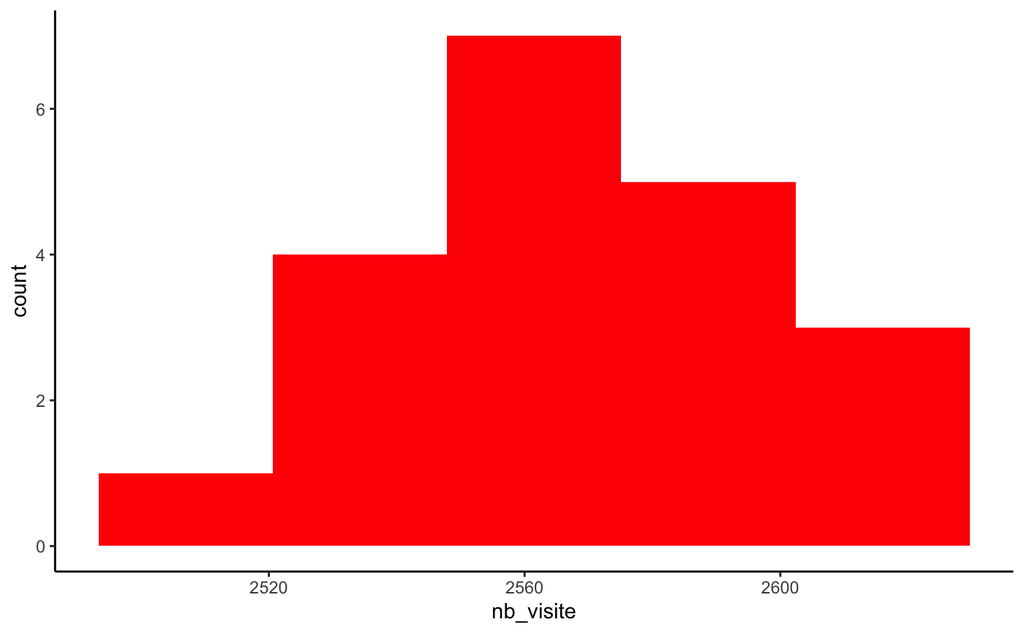

## Exercice 5.5 : Un peu de musique

1. On se connecte à la base de données et on inspecte les différentes bases.

```r
library(DBI)
conn <- dbConnect(RSQLite::SQLite(), dbname = "Chinook_Sqlite.sqlite")
dbListTables(conn)
```

```
 [1] "Album"         "Artist"        "Customer"      "Employee"      "Genre"         "Invoice"       "InvoiceLine"   "MediaType"     "Playlist"
[10] "PlaylistTrack" "Track"
```

```r
dbListFields(conn,"Playlist")
```

```
[1] "PlaylistId" "Name"
```

```r
dbListFields(conn,"PlaylistTrack")
```

```
[1] "PlaylistId" "TrackId"
```

```r
dbListFields(conn,"Track")
```

```
[1] "TrackId"      "Name"         "AlbumId"      "MediaTypeId"  "GenreId"      "Composer"     "Milliseconds" "Bytes"        "UnitPrice"
```

```r
dbListFields(conn,"Album")
```

```
[1] "AlbumId"  "Title"    "ArtistId"
```

2. On affecte les tables de la base de données à une liste de `tibbles`. On pourrait croire que c’est très gourmand en mémoire pour de gros tableaux mais en fait pas du tout. C’est juste une liste d’objets qui permettent de faire une connexion avec la base de données. Donc on peut il aller gaiment !

```r
musique <- list()
for(name in dbListTables(conn)){
  musique[[name]] <- tbl(conn, name)
}
names(musique)
```

```
 [1] "Album"         "Artist"        "Customer"      "Employee"      "Genre"         "Invoice"       "InvoiceLine"   "MediaType"     "Playlist"
[10] "PlaylistTrack" "Track"
```

La requête (après avoir regardé un peu la structure des tables) est la suivante

```r
result <- musique$Playlist %>%
  filter(Name == "Classical") %>%
  left_join(musique$PlaylistTrack, by = "PlaylistId") %>%
  left_join(musique$Track, by = "TrackId") %>%
  select(Song = Name.y, AlbumId) %>%
  left_join(musique$Album, by = "AlbumId") %>%
  select(Song, Album = Title)
```

On regarde les résultats

```r
result %>% collect()
```

| Song | Album |
| --- | --- |
| Intoitus: Adorate Deum | Adorate Deum: Gregorian Chant from the Proper of the Mass |
| Miserere mei, Deus | Allegri: Miserere |
| Canon and Gigue in D Major: I. Canon | Pachelbel: Canon & Gigue |
| Concerto No. 1 in E Major, RV 269 "Spring": I. Allegro | Vivaldi: The Four Seasons |
| Concerto for 2 Violins in D Minor, BWV 1043: I. Vivace | Bach: Violin Concertos |
| Aria Mit 30 Veränderungen, BWV 988 "Goldberg Variations": Aria | Bach: Goldberg Variations |
| Suite for Solo Cello No. 1 in G Major, BWV 1007: I. Prélude | Bach: The Cello Suites |
| The Messiah: Behold, I Tell You a Mystery... The Trumpet Shall Sound | Handel: The Messiah (Highlights) |
| Solomon HWV 67: The Arrival of the Queen of Sheba | The World of Classical Favourites |
| "Eine Kleine Nachtmusik" Serenade In G, K. 525: I. Allegro | Sir Neville Marriner: A Celebration |

[output cut: 65 more lines]

3. On peut regarder la requête SQL

```r
result %>% show_query()
```

```
<SQL>
SELECT `Song`, `Title` AS `Album`
FROM (SELECT `LHS`.`Song` AS `Song`, `LHS`.`AlbumId` AS `AlbumId`, `RHS`.`Title` AS `Title`, `RHS`.`ArtistId` AS `ArtistId`
FROM (SELECT `Name.y` AS `Song`, `AlbumId`
FROM (SELECT `LHS`.`PlaylistId` AS `PlaylistId`, `LHS`.`Name` AS `Name.x`, `LHS`.`TrackId` AS `TrackId`, `RHS`.`Name` AS `Name.y`, `RHS`.`AlbumId` AS `AlbumId`, `RHS`.`MediaTypeId` AS `MediaTypeId`, `RHS`.`GenreId` AS `GenreId`, `RHS`.`Composer` AS `Composer`, `RHS`.`Milliseconds` AS `Milliseconds`,…
FROM (SELECT `LHS`.`PlaylistId` AS `PlaylistId`, `LHS`.`Name` AS `Name`, `RHS`.`TrackId` AS `TrackId`
FROM (SELECT *
FROM `Playlist`
WHERE (`Name` = 'Classical')) AS `LHS`
LEFT JOIN `PlaylistTrack` AS `RHS`
ON (`LHS`.`PlaylistId` = `RHS`.`PlaylistId`)
) AS `LHS`
LEFT JOIN `Track` AS `RHS`
ON (`LHS`.`TrackId` = `RHS`.`TrackId`)
)) AS `LHS`
LEFT JOIN `Album` AS `RHS`
ON (`LHS`.`AlbumId` = `RHS`.`AlbumId`)
)
```

Et on n’oublie pas de se déconnecter !

```r
dbDisconnect(conn)
```

## Exercice 5.6 : Du trampoline sur Wikipedia

1. On récupère tout d’abord le tableau

```r
url <- "https://fr.wikipedia.org/wiki/Liste_des_médaillés_olympiques_au_trampoline"
tramp <- read_html(url)
tab <- tramp %>% html_table()
tramp.f <- tab[[2]]
```

2. On créé le dataframe

```r
tramp.f1 <- tramp.f %>% gather(key="med",value="ath_p",Or,Argent,Bronze) %>%
  separate(ath_p,into=c("nom","pays"),sep="\\(") %>% mutate(pays=str_remove(pays,"\\)"))
tramp.f1
```

| Édition | Lieu | med | nom | pays |
| --- | --- | --- | --- | --- |
| 2000 | Sydney | Or | Irina Karavaeva | RUS |
| 2004 | Athènes | Or | Anna Dogonadze | GER |
| 2008 | Pékin | Or | He Wenna | CHN |
| 2012 | Londres | Or | Rosannagh MacLennan | CAN |
| 2016 | Rio de Janeiro | Or | Rosannagh MacLennan | CAN |
| 2000 | Sydney | Argent | Oksana Tsyhulyeva | UKR |
| 2004 | Athènes | Argent | Karen Cockburn | CAN |
| 2008 | Pékin | Argent | Karen Cockburn | CAN |
| 2012 | Londres | Argent | Huang Shanshan | CHN |
| 2016 | Rio de Janeiro | Argent | Bryony Page | GBR |

[output cut: 5 more lines]

3.On le classe en fonction des médailles

```r
tramp.f1 %>% group_by(pays,med) %>% summarize(nomb=n()) %>% spread(med,nomb) %>% select(c(1,4,2,3)) %>%
  arrange(desc(Or,Argent,Bronze))
```

| pays | Or | Argent | Bronze |
| --- | --- | --- | --- |
| CAN | 2 | 2 | 1 |
| CHN | 1 | 1 | 3 |
| GER | 1 | NA | NA |
| RUS | 1 | NA | NA |
| GBR | NA | 1 | NA |
| UKR | NA | 1 | NA |
| UZB | NA | NA | 1 |

4. On fait la même chose pour les hommes

```r
tramp.h <- tab[[1]]
tramp.h1 <- tramp.h %>% gather(key="med",value="ath_p",Or,Argent,Bronze) %>%
  separate(ath_p,into=c("nom","pays"),sep="\\(") %>% mutate(pays=str_remove(pays,"\\)"))
tramp.h1 %>% group_by(pays,med) %>% summarize(nomb=n()) %>% spread(med,nomb) %>% select(c(1,4,2,3)) %>%
  arrange(desc(Or,Argent,Bronze))
```

| pays | Or | Argent | Bronze |
| --- | --- | --- | --- |
| CHN | 2 | 1 | 3 |
| BLR | 1 | NA | NA |
| RUS | 1 | 2 | NA |
| UKR | 1 | NA | NA |
| AUS | NA | 1 | NA |
| CAN | NA | 1 | 1 |
| GER | NA | NA | 1 |

et enfin pour le tableau mixte

```r
tramp.fh <- bind_rows(tab[[1]],tab[[2]])
tramp.fh1 <- tramp.fh %>% gather(key="med",value="ath_p",Or,Argent,Bronze) %>%
  separate(ath_p,into=c("nom","pays"),sep="\\(") %>% mutate(pays=str_remove(pays,"\\)"))
tramp.fh1 %>% group_by(pays,med) %>% summarize(nomb=n()) %>% spread(med,nomb) %>% select(c(1,4,2,3)) %>%
  arrange(desc(Or,Argent,Bronze))
```

| pays | Or | Argent | Bronze |
| --- | --- | --- | --- |
| CHN | 3 | 2 | 6 |
| CAN | 2 | 3 | 2 |
| RUS | 2 | 2 | NA |
| BLR | 1 | NA | NA |
| GER | 1 | NA | 1 |
| UKR | 1 | 1 | NA |
| AUS | NA | 1 | NA |
| GBR | NA | 1 | NA |
| UZB | NA | NA | 1 |

## Exercice 5.7 : Débouchés dans l’enseignement supérieur français

```r
df <- jsonlite::fromJSON("fr-esr-insertion_professionnelle-master.json")$fields
```

```r
df1 <- df %>% select(etablissement,salaire_net_median_des_emplois_a_temps_plein,salaire_net_mensuel_median_regional) %>%
  mutate(salaire_net_median_des_emplois_a_temps_plein=as.numeric(salaire_net_median_des_emplois_a_temps_plein),
         salaire_net_mensuel_median_regional=as.numeric(salaire_net_mensuel_median_regional))
```

```
NAs introduced by coercionNAs introduced by coercion
```

```r
df2 <- df1 %>% group_by(etablissement) %>% summarize(sal.temps.plein=mean(salaire_net_median_des_emplois_a_temps_plein,na.rm=TRUE),
                                              sal.reg=mean(salaire_net_mensuel_median_regional,na.rm=TRUE))
df2
```

| etablissement | sal.temps.plein | sal.reg |
| --- | --- | --- |
| Aix-Marseille | 1767.500 | 1799.379 |
| Amiens - Picardie Jules-Verne | 1848.936 | 1811.898 |
| Angers | 1724.688 | 1727.520 |
| Antilles et Guyane | 2020.000 | 2070.000 |
| Artois | 1795.455 | 1796.720 |
| Avignon | 1898.000 | 1799.091 |
| Besançon - Franche-Comté | 1753.696 | 1765.034 |
| Bordeaux | 1843.733 | 1727.843 |
| Bordeaux - Montaigne | 1605.758 | 1722.500 |
| Bordeaux 1 - Sciences technologies | 1968.000 | 1680.000 |

[output cut: 73 more lines]

2. On classe selon le ratio demandé.

```r
df2 %>% mutate(ratio=sal.temps.plein/sal.reg) %>% arrange(desc(ratio))
```

| etablissement | sal.temps.plein | sal.reg | ratio |
| --- | --- | --- | --- |
| Montpellier 1 | 2020.000 | 1655.556 | 1.2201342 |
| Bordeaux 4 - Montesquieu | 1987.500 | 1680.000 | 1.1830357 |
| Bordeaux 1 - Sciences technologies | 1968.000 | 1680.000 | 1.1714286 |
| Paris 2 - Panthéon Assas | 2376.957 | 2031.667 | 1.1699540 |
| Montpellier 2 - Sciences techniques du Languedoc | 1890.000 | 1655.714 | 1.1415013 |
| Rennes 1 | 1882.667 | 1711.682 | 1.0998926 |
| La Réunion | 2048.421 | 1871.250 | 1.0946806 |
| Toulouse 3 - Paul Sabatier | 1922.812 | 1771.136 | 1.0856378 |
| Toulouse 1 - Capitole | 1919.024 | 1770.000 | 1.0841946 |
| Clermont-Ferrand 1 - Auvergne | 1872.727 | 1743.115 | 1.0743568 |

[output cut: 73 more lines]